# Jasmine Dumas

Data Scientist

:e-mail: : jasmine.dumas[at]gmail.com | :pencil: : [jasdumas.github.io](https://jasdumas.github.io/) | :scroll: : [PDF resume version](http://jasdumas.github.io/jasmine_dumas_resume.pdf)

### About Me

I’m a Data Scientist & Engineer with industry experience in financial technology, auto insurance, medical devices, R&D, and aerospace manufacturing. I’m an active member of the R programming community and have developed several open source packages and participated in [Google Summer of Code](https://www.google-melange.com/archive/gsoc/2015/orgs/rproject/projects/jasdumas.html), and [NASA Datanauts](https://open.nasa.gov/blog/welcome-datanauts-2017-spring-class/).

### Objective

I’m searching for a **remote-friendly** company that values creativity, diversity and openness as a **lead or Sr. Data Scientist** developing data products & algorithms with R & Python while mentoring junior team members.

### Education

- **Graduate Analytics Certificate** at [DePaul University](https://www.cdm.depaul.edu/academics/Pages/Current/Analytics-Certificate.aspx), (2015 - expected Fall 2017)
- *Coursework*: Intro to Programming, Data Analytics & Regression, Database Processing for Large-scale Analytics, Advanced Data Analysis, Knowledge Discovery Technologies, Programming Machine Learning Applications
- **Bachelor of Science in Engineering in Biomedical Engineering** at [University of Hartford](http://www.hartford.edu/ceta/undergraduate/engineering/BM/), (2008 - 2012)
- *Coursework*: Engineering Computer Applications, Calculus (1-2, Multivariable), Differential Equations, Research, Engineering Design, Statics, Dynamics, Mechacnics of Materials, Biomaterials

### Data Science Work Experience

- **Data Scientist 2 at Simple Finance**, (Oct. 2016 - Present)
  - Lead Data Scientist for the Onboarding product team: responsible for technical mentorship, data product strategy, external data integration with APIs and experimentation design and analysis (A/B Testing)
  - Developed an early detection predictive model using **feature selection with Gradient Boosted Models** to monitor spikes in ACH returns leading to data-informed decisions for mitigating fraud loss partnered with the risk team
  - Developed a rapid prototype using `r-shiny` and `flexdashboard` for performing power analysis
  - Modeled causal impact with Bayesian structural **time series techniques** for fraud prevention and product feature launches
- **Associate Data Scientist at The Hartford Financial Services**, (April 2016 - Oct. 2016)
- **Data Science Intern at The Hartford Financial Services**, (Nov. 2015 - March 2016)
  - Research & Implementation of machine learning techniques in **variable reduction and selection** to develop predictive models for auto insurance that improve loss ratio estimates, drive strategic pricing changes and insights on competitive position.
  - Enhancing the team’s data science architecture by developing and maintaining an internal **R** package, writing technical documentation and tutorials.
- **Bioinformatics Internship at the University of Connecticut Institute for Systems Genomics (UConn)**, (Sept. 2015 - January 2016)
  - Computational and command line programming to develop a gene database for the annotation of the douglas-fir & walnut genome.
- **Student Developer at Google Summer of Code**, (May 2015 - Aug. 2015)
  - Developed a web application with `r-shiny` to automate differential expression and survival analysis of micro-array gene expression datasets from the NIH Gene Expression Omnibus

### Featured Projects

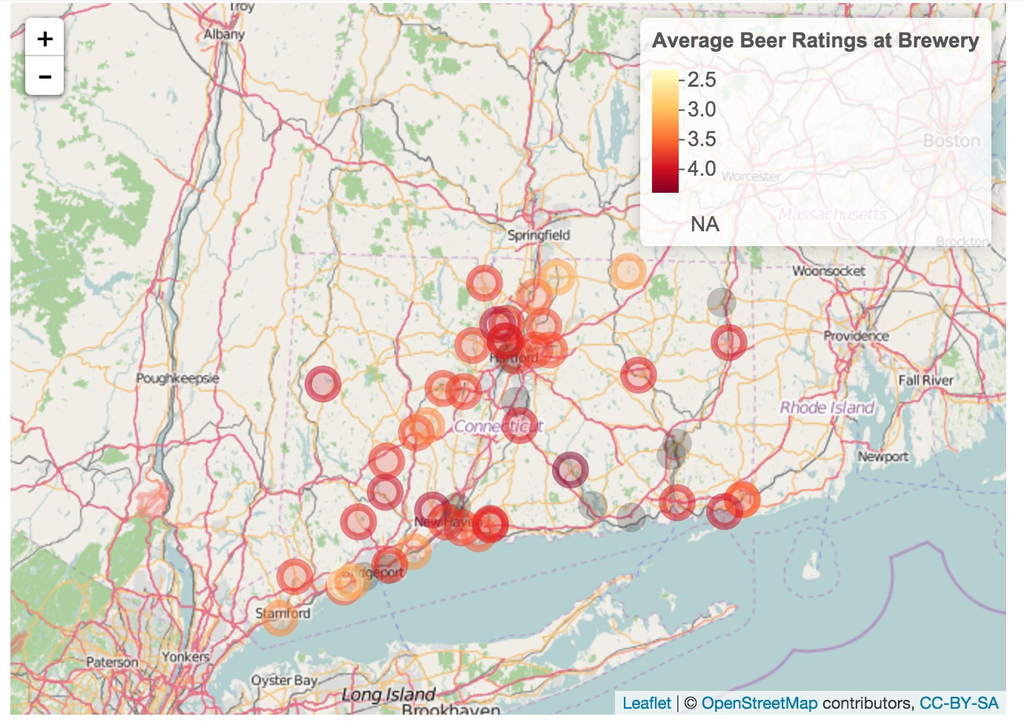

[figure not shown]

**Tutorial on Web scraping craft brewery ratings from Beer Advocate with R and import.io** [Details](http://trendct.org/2016/03/18/tutorial-web-scraping-and-mapping-breweries-with-import-io-and-r/)

**R-Shiny app for gene expression analysis for bioinformaticians** [Details](http://gdancik.github.io/shinyGEO/)

*More projects available at: https://jasdumas.github.io/projects/*

### Open Source `R` Software

- [**`gramr`**](https://github.com/ropenscilabs/gramr): CLI wrapper for grammar checks in RMarkdown documents
- [**`ttbbeer`**](https://CRAN.R-project.org/package=ttbbeer): Data package of beer statistics from U.S. Department of the Treasury (TTB)
- [**`shinyLP`**](https://CRAN.R-project.org/package=shinyLP): Bootstrap Components to make landing home pages for shiny web apps
- [**`shinyGEO`**](http://jasdumas.github.io/shinyGEO/): Shiny app for gene expression differential & survival analysis

*More R packages and Shiny apps available at: https://github.com/jasdumas*

### Talks

- [Adventures in Crafting a Data Science Career](https://jasdumas.github.io/talks/rhodyrstats-R-user-group/rhodyrstats-r-user-group-slides.html) - University of Rhode Island (URI) Coastal Institute and RhodyRStats “Careers in R” speaker series in *Narragansett, RI*
- [Extending Shiny by Enhancing User Experience with shinyLP](https://jasdumas.github.io/talks/PDX-R-user-group/pdx-r-user-group-slides.html) - R User Group in *Portland, OR*
- [Open Government Data & Beer Analytics](https://jasdumas.github.io/talks/odsc-boston/odsc-open-gov-beer.html) - Open Data Science Conference 2017 in *Boston, MA*

### Research Publications

- **Dumas J**, Gargano MA, Dancik GM. *shinyGEO: a web-based application for analyzing Gene Expression Omnibus datasets*. Bioinformatics. 2016 Aug 8. - [Paper link](http://bioinformatics.oxfordjournals.org/content/early/2016/08/20/bioinformatics.btw519)
- **Dumas J**, et.al., *Feasibility of an electronic stethoscope system for monitoring neonatal bowel sounds*. Connecticut Medicine, Volume 77, Number 8, pp. 467-471, September 2013. - [Paper link](http://connmed.csms.org/i/157293-sept-2013/20)

### Technical Skills

- Computational programming & machine learning with R and Python
- Statistical Analysis and inference
- Data processing & querying with SQL
- Web application development with Shiny and Bootstrap
- Collaborative computing with GitHub and Git